# MA710-A2- College Scorecard Association Rules & Cluster Analysis

Xiang Li, Xue Zhou

March 21, 2017

# Table of Contents

- 1.Introduction
- 2.Association Rule Analysis
- 2.1 Goal
- 2.2 Data Preparation
- 2.3 Objective
- 2.4 Association Rule Analysis - Median earnings six years after entry
- 2.5 Conclusions - Association Rule Analysis for Median earnings six years after entry
- 2.6 Association Rule Analysis - Predominant Degree
- 2.7 Conclusions - Association Rule Analysis for Predominant Degree
- 3.Cluster Analysis
- 3.1 Goal
- 3.2 Data Preparation
- 3.3 Objective
- 3.4 Cluster Analysis - K means
- 3.5 Cluster Analysis - PAM
- 3.6 Cluster Analysis - Hierarchical
- 3.7 Cluster Validation and Comparison
- 3.8 Interpretation of 3-cluster hierarchical solution
- 3.9 Findings and Conclusion
- 4 Future Study

# 1. Introduction

In this analysis, we used **Association Rule Analysis** and **Cluster Analysis** to study the College Scorecard Data. The analysis consists of two parts. In the first part, we used **Association Rule Analysis** to detect the co-occurring associations between different variables and identified the most important relationships. In the second part, we used **Cluster Analysis** to obtain clusters of colleges that share the common characteristics so that we could better understand the profile of different institutions.

# 2. Association Rule Analysis

## 2.1. Goal

At the first stage(Assignment1), we’ve explored the relationships between pairs of variables in the College Scorecard data set. In this analysis, we mainly focused on two variables we were most interested in: the students’ **post-graduation earnings** and the institutions’ **predominant degree types**. We used Association Rule Analysis to explore the relationships between post-graduation earnings, predominant degree and the other variables. The clean data set in Assignment 1 - `data_clean.csv` was the data set we used in this study.

## 2.2 Data Preparation

First, we loaded all the packages required for analysis as below and imported the data set.

```r
  library(readr)
  library(dplyr)
  library(ggplot2)
  library(tidyr)
  library(ggvis)
  library(plyr)
  library(arules)
  library(arulesViz)
  library(cluster)
  library(clValid)

  data = read.csv("data_clean.csv",
                   header = TRUE, na.strings = 'NA')
```

As seen from the code block, `data` is the original data set we used in this analysis

`Column X`, `UNITID`, `INSTNM_factor` and `MD_EARN_WNE_P10` are not related to our analysis goal, so we removed these four variables. Then we renamed the column names, making them easy to understand.

```r
  data_asso = data[,-c(1,2,3,17)]
  #data_asso = na.omit(data_asso)
  data_asso %>% dplyr::rename(state = STABBR_factor,
                       pred_degree = PREDDEG_factor,
                       control = Control_factor,
                       net_cost = NPT4_COMBINE,
                       per_independent = DEP_STAT_PCT_IND,
                       per_1generation = PAR_ED_PCT_1STGEN,
                       median_family_inc =MD_FAMINC,
                       per_pell = PCTPELL,
                       per_loan = PCTFLOAN,
                       debt_grad = GRAD_DEBT_MDN,
                       debt_non_grad = WDRAW_DEBT_MDN,
                       per_app_greater2 = APPL_SCH_PCT_GE2,
                       median_earning_6years = MD_EARN_WNE_P6,
                       repayment_rate = RPY_3YR_RT_SUPP,
                       default_rate = CDR3) %>%
                       {.} -> data_asso
```

The `data_asso` is the resulting data set.

To make the data set appropriate for Association Rule Analysis, we encoded all the numeric variables into categorical variables with appropriate levels. We used the following function `make.ntiles` to perform this conversion.

```r
  # create factor variables from all of the numeric variables you chose to work with using the make.ntiles function.
  make.ntiles = function (inputvar, n) {
    inputvar %>%
  quantile(.,
  (1/n) * 1:(n-1),
               na.rm=TRUE
      ) %>%
  c(-Inf, ., Inf) %>% cut(inputvar,
  breaks=.,
  paste("Q", 1:n, sep="") )
  }
```

With the above function, we converted each numeric variable into a factor variable with n levels. In this case, we decided to encode all the numeric variables into 3 categories, thus n = 3.

Then we applied the `make.ntiles` function to every numeric column. After the variables were encoded, we combined them with the original three categorical variables to generate a complete data set.

```r
  data_asso %>%
    sapply(.,is.numeric) %>%
      data_asso[,.] %>%
        apply(.,make.ntiles, n=3, MARGIN = 2) %>%
           as.data.frame()   %>%
               {.} -> data_num
  data_clean = cbind(data_num,data_asso[,c(1,2,3)])
```

The data set `data_clean` is the resulting data set from the above code block. In terms of the values in the encoded variables, the Q1 is the range of the low value, the Q2 is the range for the medium value and the Q3 is the range of the high value.

## 2.3 Objective

Specifically, we have two objectives in this part:  
1.To identify the attributes that have notable relationships with the post-graduation earnings so that these variables can be used to predict the post-graduate earnings in the future.  
2.To find the relationship between predominant degree type and other variables so that we can profile institutions of different degree types.

## 2.4 Association Rule Analysis - Median earnings six years after entry

Then we started generating association rules for the median earnings six years after entry.

We used the `parameter`, `appearance` and `control` parameters of the `apriori` command to set the requirements for the rules.

The `appearance` parameter set the right-hand side(RHS) and left-hand side(LHS) of rules. In this case, we obtained the rules with RHS limited to the values in column `median_earning_6years`.

The `parameter` parameter required that all the rules must have a support value greater than 0.05 and a confidence value greater than 0.8. The `minlen` and `maxlen` parameters specified that all rules should have a length between 2 to 4.

The `control` parameter decided whether the progress of generating rules would be displayed.

```r
  #filter the rhs to the MD_EARN_WNE_P6.F column.
  apriori.appearance_e = list(rhs=c('median_earning_6years=Q1','median_earning_6years=Q2','median_earning_6years=Q3'), default='lhs')
  apriori.parameter_e = list(support=0.05,
                           confidence=0.8,minlen=2, maxlen=4)
  apriori.control_e = list(verbose=FALSE)
  rules_earning = apriori(data_clean,
                   parameter=apriori.parameter_e,
                   appearance=apriori.appearance_e,
                   control=apriori.control_e)
  length(rules_earning)
```

```
## [1] 95
```

In total, there are **95 rules**, given the parameters we specified before.

Then we would like to remove the redundant rules. A rule is considered redundant if there exists a more general rule with the same or a higher predictive power. Since the redundant rules provide no extra information, we need to remove these rules. We used lift as a measurement of predictive power to determine the redundant rules. After removing redundant rules, we also examined the number of rules for each earnings range.

```r
  rules.sorted <- sort(rules_earning, by="lift")

  ## redundant rules
  rules_redundant = rules.sorted[is.redundant(rules.sorted)]
  rules_redundant
```

```
## set of 8 rules
```

```r
  ## non-redundant rules
  rules_pruned = rules.sorted[!is.redundant(rules.sorted)]
  rules_pruned
```

```
## set of 87 rules
```

```r
  ##The number of rules associated with rhs of median_earning_6years=Q1
  rules_Q1 = subset(rules_pruned, subset = items %in% "median_earning_6years=Q1")
  length(rules_Q1)
```

```
## [1] 0
```

```r
  ##The number of rules associated with rhs of median_earning_6years=Q2
  rules_Q2 = subset(rules_pruned, subset = items %in% "median_earning_6years=Q2")
  length(rules_Q2)
```

```
## [1] 3
```

```r
  ##The number of rules associated with rhs of median_earning_6years=Q3
  rules_Q3 = subset(rules_pruned, subset = items  %in% "median_earning_6years=Q3")
  length(rules_Q3)
```

```
## [1] 84
```

From the output, there are 8 redundant rules, so we only focused on the remaining **87 rules**. Among the 87 valid rules, 84 of them have a RHS of `median_earning_6years=Q3`, 3 of them have the RHS of `median_earning_6years=Q2`, while no rules contain the RHS of `median_earning_6years=Q1`.

In the following part, we sorted the rules by support, confidence and lift respectively and looked at them more closely.

With the following code, we sorted the resulting rules by support. We then inspected the top 5 rules. A balloon graph visualizing the top 5 rules was also displayed.

```r
  #sort by support
  rules_support = sort(rules_pruned,by="support", decreasing = T)
  inspect(rules_support[1:5])
```

```
##     lhs                                rhs                          support confidence     lift
## [1] {median_family_inc=Q3,
##      debt_non_grad=Q3,
##      repayment_rate=Q3}             => {median_earning_6years=Q3} 0.1256256  0.8090909 3.231802
## [2] {per_1generation=Q1,
##      per_app_greater2=Q3,
##      repayment_rate=Q3}             => {median_earning_6years=Q3} 0.1158732  0.8048128 3.214714
## [3] {per_1generation=Q1,
##      debt_non_grad=Q3,
##      repayment_rate=Q3}             => {median_earning_6years=Q3} 0.1147183  0.8201835 3.276110
## [4] {per_1generation=Q1,
##      per_pell=Q1,
##      repayment_rate=Q3}             => {median_earning_6years=Q3} 0.1121519  0.8245283 3.293464
## [5] {debt_non_grad=Q3,
##      repayment_rate=Q3,
##      pred_degree=Bachelor's-degree} => {median_earning_6years=Q3} 0.1117670  0.8035055 3.209492
```

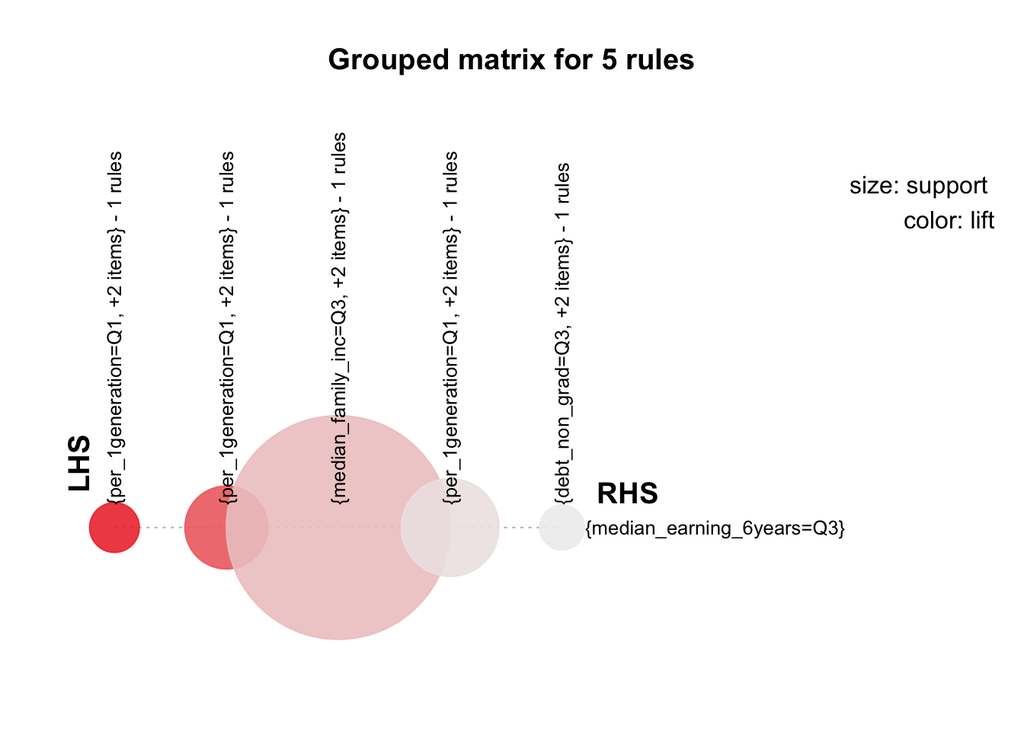

```r
  plot(head(sort(rules_pruned, by="support"), 5),
    method="grouped")
```

Based on the output, the RHS of the rules with highest support value are all `median_earning_6years=Q3`. Let’s take the first rule as an example. The support value of 0.1256 is the frequency of the this rule, which means that in the data set, 12.56% of the universities have high median family incomes, high debt amount before graduation, high repayment rate and high median earnings 6 years after they were enrolled.

The confidence value is 0.8091, indicating that 80.91% of the universities whose students have high median family income, high debt amount before graduation and high repayment rate tend to have students with high median earning 6 years after the enrollment.

Then we ordered the 87 rules by confidence and pulled out the top 5 rules. The code below generates a balloon graph visualizing these 5 rules.

```r
  rules_confidence = sort(rules_pruned,by="confidence", decreasing = T)
  inspect(rules_confidence[1:5])
```

```
##     lhs                     rhs                           support confidence     lift
## [1] {per_pell=Q1,
##      debt_non_grad=Q3,
##      default_rate=Q1}    => {median_earning_6years=Q3} 0.07211600  0.9093851 3.632413
## [2] {per_1generation=Q1,
##      debt_non_grad=Q3,
##      default_rate=Q1}    => {median_earning_6years=Q3} 0.08122674  0.8865546 3.541220
## [3] {per_pell=Q1,
##      debt_grad=Q3,
##      default_rate=Q1}    => {median_earning_6years=Q3} 0.06685487  0.8860544 3.539222
## [4] {debt_non_grad=Q3,
##      repayment_rate=Q3,
##      default_rate=Q1}    => {median_earning_6years=Q3} 0.08674451  0.8836601 3.529658
## [5] {per_independent=Q1,
##      debt_non_grad=Q3,
##      default_rate=Q1}    => {median_earning_6years=Q3} 0.07288592  0.8819876 3.522978
```

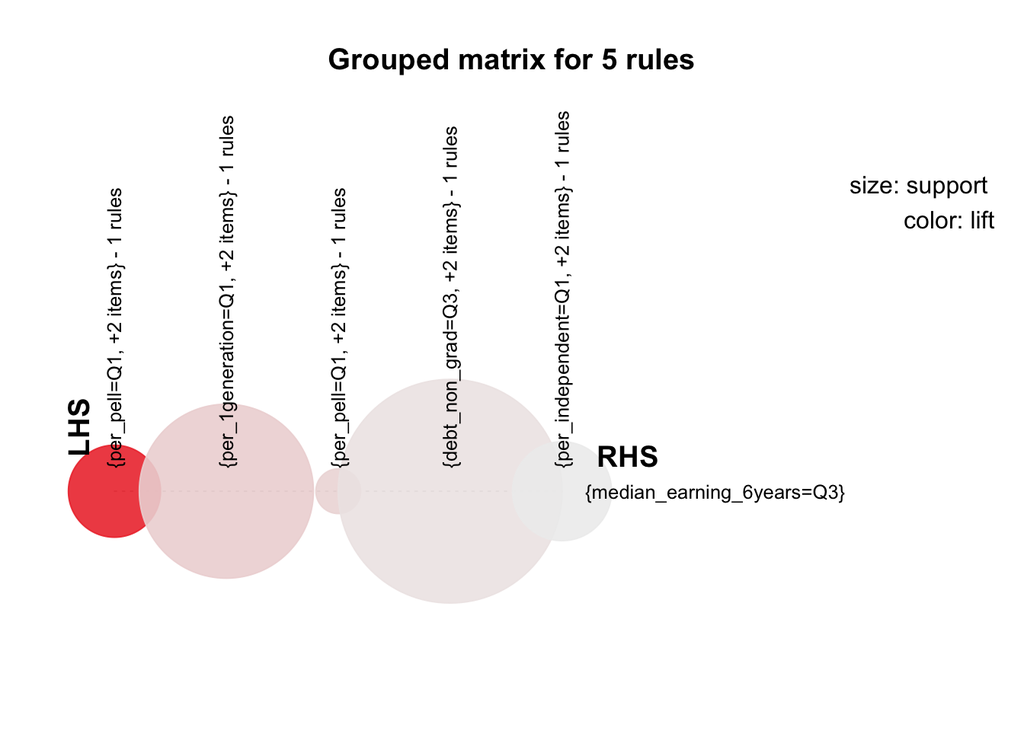

```r
  plot(head(sort(rules_pruned, by="confidence"), 5),
    method="grouped")
```

Generally speaking, a high confidence value indicates that the frequency of the right-hand side occurring given the left-hand side occurs is high. So rules here would be useful to predict right-hand side if we already know the left-hand side.

Since most rules have RHS `median_earning_6years=Q3`, all these five rules indicates the relationship between post-graduation earnings and the other variables. Tops Rules here are slightly different from the rules sorted by support, but **still center on the factors including the pell grant, the debt amount and the percentage of the first generation student**.

Lastly, we sorted the rules by lift value and further inspect the top 5 rules.

```r
  rules_lift = sort(rules_earning,by="lift", decreasing = T)
  inspect(rules_lift[1:5])
```

```
##     lhs                     rhs                           support confidence     lift
## [1] {per_pell=Q1,
##      debt_non_grad=Q3,
##      default_rate=Q1}    => {median_earning_6years=Q3} 0.07211600  0.9093851 3.632413
## [2] {per_1generation=Q1,
##      debt_non_grad=Q3,
##      default_rate=Q1}    => {median_earning_6years=Q3} 0.08122674  0.8865546 3.541220
## [3] {per_pell=Q1,
##      debt_grad=Q3,
##      default_rate=Q1}    => {median_earning_6years=Q3} 0.06685487  0.8860544 3.539222
## [4] {debt_non_grad=Q3,
##      repayment_rate=Q3,
##      default_rate=Q1}    => {median_earning_6years=Q3} 0.08674451  0.8836601 3.529658
## [5] {per_independent=Q1,
##      debt_non_grad=Q3,
##      default_rate=Q1}    => {median_earning_6years=Q3} 0.07288592  0.8819876 3.522978
```

From the output, the rule with the highest lift value is identical with the rule with the highest confidence value (as we can tell from the previous session), which means that there exists a notable relationship between LHS (low Pell percentage value, high debt before graduation and low default rate value and RHS (high median post-graduation earnings after enrollment). Likewise, other top rules sorted by lift also center on **factors including pell grant, debt amount, the percentage of generation student and repayment condition**.

## 2.5 Conclusions - Association Rules Analysis for Median earning six years after entry

Based on the above analysis, we can conclude that if a college has a low percentage of Pell Grant students, a low default rate, a high repayment rate and students from a well-educated family background, its students are more likely to have high earnings after graduation. Thus we identified some potential variables predicting students’ post-graduation earnings in a college: **percentage of pell grant students, default rate, repayment rate, family income and the percentage of the first-generation students**.

## 2.6 Association Rule Analysis - Predominant Degree

The second part of association rule analysis was focused on the relationship between the predominant degree type and the other variables. As the code below shows, we limited the RHS to the three levels of the predominant degree type. Additionally, we set the minimum support to 0.1, which means that the algorithm would only keep the rules with a frequency greater than 10%. Likewise, the minimum confidence was set to 0.8, which means that we would only keep the rules with the conditional probability greater than 0.8.

```r
  apriori.appearance = list(rhs = c("pred_degree=Bachelor's-degree","pred_degree=Certificate-degree",
                                    "pred_degree=Associate's-degree","pred_degree=NotClassified",
                                    "pred_degree=Graduate-degree"),
                            default = 'lhs')

  apriori.parameter = list(support = 0.10,
                            confidence =0.8)
  apriori.control = list(verbose = FALSE)
  rules_degree = apriori(data_clean,
                  parameter = apriori.parameter,
                  appearance = apriori.appearance,
                  control = apriori.control)
  length(rules_degree)
```

```
## [1] 225
```

In total, we got **225 association rules**.

Like what we did in the 2.4 session, we used **lift** to determine and remove the redundant rules.

```r
  rules_degree_sorted <- sort(rules_degree, by="lift")
  length(rules_degree_sorted)
```

```
## [1] 225
```

```r
  ## redundant rules
  rules_degree_redundant = rules_degree_sorted[is.redundant(rules_degree_sorted)]

  ## non-redundant rules
  rules_degree_pruned = rules_degree_sorted[!is.redundant(rules_degree_sorted)]

  rules_degree_redundant
```

```
## set of 30 rules
```

```r
  rules_degree_pruned
```

```
## set of 195 rules
```

After removing the redundant rules, we got the **195 rules**. We further analyzed these rules in the following sections.

With the following code block, we first sorted the rules by their support, we then examined the top 5 rules.

```r
  inspect(sort(rules_degree_pruned,by='support')[1:5])
```

```
##     lhs                             rhs                                support confidence     lift
## [1] {debt_non_grad=Q1,
##      control=Private For-profit} => {pred_degree=Certificate-degree} 0.1932504  0.8518100 1.969195
## [2] {median_family_inc=Q3,
##      per_app_greater2=Q3}        => {pred_degree=Bachelor's-degree}  0.1682279  0.8828283 3.231508
## [3] {median_family_inc=Q3,
##      debt_non_grad=Q3}           => {pred_degree=Bachelor's-degree}  0.1607853  0.8671280 3.174039
## [4] {per_independent=Q1,
##      per_app_greater2=Q3}        => {pred_degree=Bachelor's-degree}  0.1582189  0.8387755 3.070257
## [5] {median_family_inc=Q3,
##      debt_grad=Q3}               => {pred_degree=Bachelor's-degree}  0.1562941  0.8884026 3.251912
```

Among top five rules sorted by support, four rules are regarding Bachelor degree while the very top rule is for certificate degree. For the first rule, a support value as high as 19% means that around 19% of institutions in the data set satisfy the following characteristics: private for-profit, certificate-predominant and with students having low debts. As we discussed before, a high support value shows that the rule is more likely to generalize well in other institutions.

The other four rules regarding Bachelor degree indicate that if most students in a school are from a wealthy and educated family and willing to apply for more debts, the school is more likely to belong to Bachelor degree predominant type.

Then we looked at the rules sorted by confidence. Likewise, we would only focus on the top 5 rules.

```r
  inspect(sort(rules_degree_pruned,by='confidence')[1:5])
```

```
##     lhs                       rhs                               support confidence     lift
## [1] {per_1generation=Q1,
##      median_family_inc=Q3,
##      per_pell=Q1,
##      per_app_greater2=Q3,
##      repayment_rate=Q3}    => {pred_degree=Bachelor's-degree} 0.1021429  0.9731051 3.561958
## [2] {per_1generation=Q1,
##      per_pell=Q1,
##      per_app_greater2=Q3,
##      repayment_rate=Q3}    => {pred_degree=Bachelor's-degree} 0.1029129  0.9685990 3.545464
## [3] {per_1generation=Q1,
##      per_pell=Q1,
##      debt_non_grad=Q3}     => {pred_degree=Bachelor's-degree} 0.1007314  0.9643735 3.529996
## [4] {median_family_inc=Q3,
##      per_pell=Q1,
##      debt_grad=Q3,
##      repayment_rate=Q3}    => {pred_degree=Bachelor's-degree} 0.1003465  0.9642417 3.529514
## [5] {per_pell=Q1,
##      debt_grad=Q3,
##      repayment_rate=Q3}    => {pred_degree=Bachelor's-degree} 0.1008597  0.9632353 3.525830
```

Top 5 rules are all about Bachelor degree. A high confidence indicates a strong relationship between LHS and RHS, so we can say that if we observe the existence of LHS, the RHS is very likely to happen. For example, for the first rule, if a institution has low percentage of first-generation students, low percentage of students receiving the pell grant, high median family income, good repayment condition and more students applying to more than 2 school, this institution is 97% likely to provide Bachelor degree as predominant degree.

We then sorted all 195 rules by the lift value. If the lift value equals to 1, it would imply that the probability of the occurrence of LHS and the probability of occurrence of the RHS are independent. With that said, the higher the lift value is, the more strongly the LHS and RHS are associated.

```r
  inspect(sort(rules_degree_pruned,by='lift')[1:5])
```

```
##     lhs                       rhs                               support confidence     lift
## [1] {per_1generation=Q1,
##      median_family_inc=Q3,
##      per_pell=Q1,
##      per_app_greater2=Q3,
##      repayment_rate=Q3}    => {pred_degree=Bachelor's-degree} 0.1021429  0.9731051 3.561958
## [2] {per_1generation=Q1,
##      per_pell=Q1,
##      per_app_greater2=Q3,
##      repayment_rate=Q3}    => {pred_degree=Bachelor's-degree} 0.1029129  0.9685990 3.545464
## [3] {per_1generation=Q1,
##      per_pell=Q1,
##      debt_non_grad=Q3}     => {pred_degree=Bachelor's-degree} 0.1007314  0.9643735 3.529996
## [4] {median_family_inc=Q3,
##      per_pell=Q1,
##      debt_grad=Q3,
##      repayment_rate=Q3}    => {pred_degree=Bachelor's-degree} 0.1003465  0.9642417 3.529514
## [5] {per_pell=Q1,
##      debt_grad=Q3,
##      repayment_rate=Q3}    => {pred_degree=Bachelor's-degree} 0.1008597  0.9632353 3.525830
```

Based on the output, some rules with the high confidence value also have very high lift values(as we can tell from the previous discussions). A rule with a high confidence and lift value indicates a strong relationship between LHS and RHS.

In the following session, we used some visualizations to better understand the total 195 rules. We drew the scatter plot to visualize the relationships between support, confidence and lift.

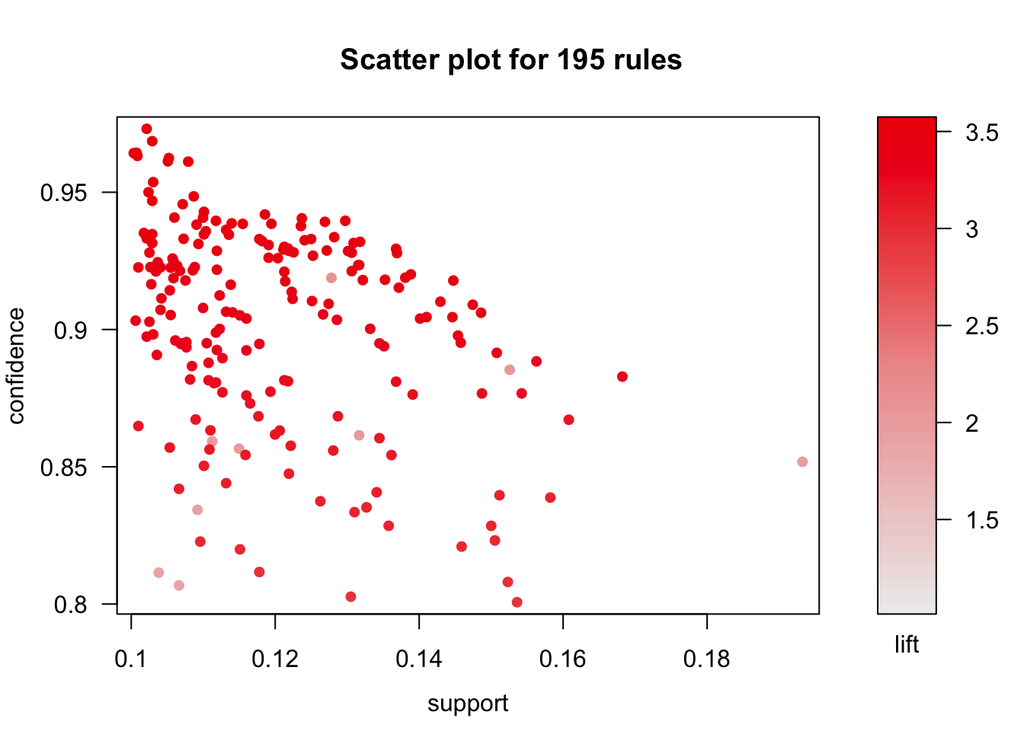

```r
  plot(rules_degree_pruned, method = NULL, measure = "support", shading = "lift",
        interactive = FALSE, data = NULL, control = NULL)
```

The plot shows a roughly negative relationship between confidence and support. However, the relationship between lift and the other two is not obvious.

## 2.7 Conclusions - Association Rules Analysis for Predominant Degree

As a conclusion, all the rules we found in this session describes the institutions whose predominant degree are **either bachelor or certificate**. No explicit association was detected between other degree types and the variables. **If most students in a school are from a wealthy and well-educated family, taking more debt for their education, and less likely to apply for Pell grant, their institutions are likely to be bachelor-predominant**.

Moreover, **if an institution is a private for-profit school whose students usually have lower debt amount before graduation and lower earnings six years after graduation, the school is more likely to be certificate-predominant**.

# 3. Cluster Analysis

## 3.1 Goal

By performing Cluster Analysis on College Scoreboard data, we would like to find the groups of similar institutions and to characterize the institutions in these groups. The clustering result can help us better understand the profiles of institutions and how they are different from each other.

## 3.2 Data Preparation

In the following analysis, we used the `data_clean` data set in assignment 1 but we did some transformation on this data set to make it appropriate for Clustering Analysis.

`University name`, `ID`, and `state columns` are not useful in Clustering Analysis since they are either identifiers or variable with too many levels, thus we removed these three columns along with the index column generated by R when importing data.

```r
  data_c = read.csv("data_clean.csv",
                   header = TRUE, na.strings = 'NA')

  #get rid of ID, university name and state columns, rename the rownames as the university ID.
  data.with.rownames <- data.frame(data_c[,-c(1:4)], row.names=data_c[,2])
  glimpse(data.with.rownames)
```

```
## Observations: 7,793
## Variables: 15
## $ PREDDEG_factor    <fctr> Bachelor's-degree, Bachelor's-degree, Bache...
## $ Control_factor    <fctr> Public, Public, Private Nonprofit, Public, ...
## $ NPT4_COMBINE      <int> 11726, 15123, 6927, 11160, 11029, 18526, 731...
## $ DEP_STAT_PCT_IND  <dbl> 0.15766924, 0.33031333, 0.90719258, 0.378064...
## $ PAR_ED_PCT_1STGEN <dbl> 0.3697641, 0.3459119, 0.4957265, 0.3248731, ...
## $ MD_FAMINC         <dbl> 22681.34, 35359.88, 18409.75, 33376.83, 2044...
## $ PCTPELL           <dbl> 0.7011, 0.3680, 0.8688, 0.3345, 0.7752, 0.22...
## $ PCTFLOAN          <dbl> 0.7935, 0.5529, 0.9679, 0.4787, 0.8157, 0.42...
## $ GRAD_DEBT_MDN     <dbl> 30000.0, 20500.0, 20168.0, 21500.0, 31000.0,...
## $ WDRAW_DEBT_MDN    <dbl> 10064.0, 8650.0, 5644.5, 8305.5, 9500.0, 750...
## $ APPL_SCH_PCT_GE2  <dbl> 0.7347901, 0.4988675, 0.6380510, 0.5191398, ...
## $ MD_EARN_WNE_P6    <int> 22000, 33300, 35200, 35900, 20300, 33200, 23...
## $ MD_EARN_WNE_P10   <int> 30300, 39700, 40100, 45500, 26600, 41900, 27...
## $ RPY_3YR_RT_SUPP   <dbl> 0.2427035, 0.5484434, 0.3201581, 0.5732784, ...
## $ CDR3              <dbl> 0.165, 0.070, 0.075, 0.084, 0.190, 0.082, 0....
```

The resulting `data_c` data set contains 15 variables with 7793 observations.

Since most distance measurements, like Euclidean Distance and Cosine Distance, are only valid for numeric variables, we converted the factor variables into binary dummy variables.

```r
  # Create the dummy boolean variables using the model.matrix() function.
  dummy_preddeg = model.matrix(~PREDDEG_factor-1, data.with.rownames)
  dummy_control = model.matrix(~Control_factor-1, data.with.rownames)
```

The `dummy_preddeg` and `dummy_control` are dummy variables for `PREDDEG_factor` and `Control_factor`.

In order to make the column name of 8 dummy variables easy to understand, we renamed these variables with the appropriate names and then combined them with the original 13 continuous variables. We also removed the records with any missing value since the clustering algorithms could not handle missing values.

```r
  #rename the coloumn names for dummay variables to make them more readable.
  colnames(dummy_preddeg) <- gsub("PREDDEG_factor","",colnames(dummy_preddeg))
  colnames(dummy_control) <- gsub("Control_factor","",colnames(dummy_control))

  #Combine the matrix back with the original dataframe.
  data_combine_c= cbind(data.with.rownames, dummy_preddeg,dummy_control)

  #git rid of the factor coloumns which have been converted to the dummy variable.
  data_ready = data_combine_c[,-c(1:2)]

  #remove the missing values
  data_ready %>%
    na.omit(data_ready) %>%
    {.} -> data_clean_c
```

In the data set `data_clean_c`, all variables are now numeric and appropriate for Clustering Analysis.

To ensure that every variable receives the same weight, we then standardized the numeric variables in the data set. We also noticed the `Graduate-degree` only contained 0, which means that it couldn’t provide any additional information. So, we removed this column.

```r
  #delete the 17 col since its all 0
  data_final= data.frame(scale(data_clean_c[,-17]))
```

The resulting `data_final` is the clean data set for analysis, with 4,528 observations and 20 columns.

## 3.3 Objective

As we mentioned before, the goal of this Clustering Analysis is to understand the profile of institutions and to see how they are different from each other. More specifically, we have following three objectives:

1. For each cluster, to create a concrete profile for institutions in this clusters.
2. To identify variables that differentiate one cluster from another.
3. To see if some characteristics tend to occur together (like high repayment usually comes with low default rate).

In the following analysis, we are going to use three clustering methods: K-means, PAM and Hierarchical. For each method, we identified the best number of clusters. And then we will compared the different methods using `clValid` function to select the best model.

## 3.4 Cluster Analysis process - K-means

We set the seed value to 100 so that we could reproduce the analysis later.

```r
  set.seed(100)
```

To determine the optimum k value for clustering the observations, we used scree plots to display the ratio of WSS and TSS for 1 cluster to 7 clusters.

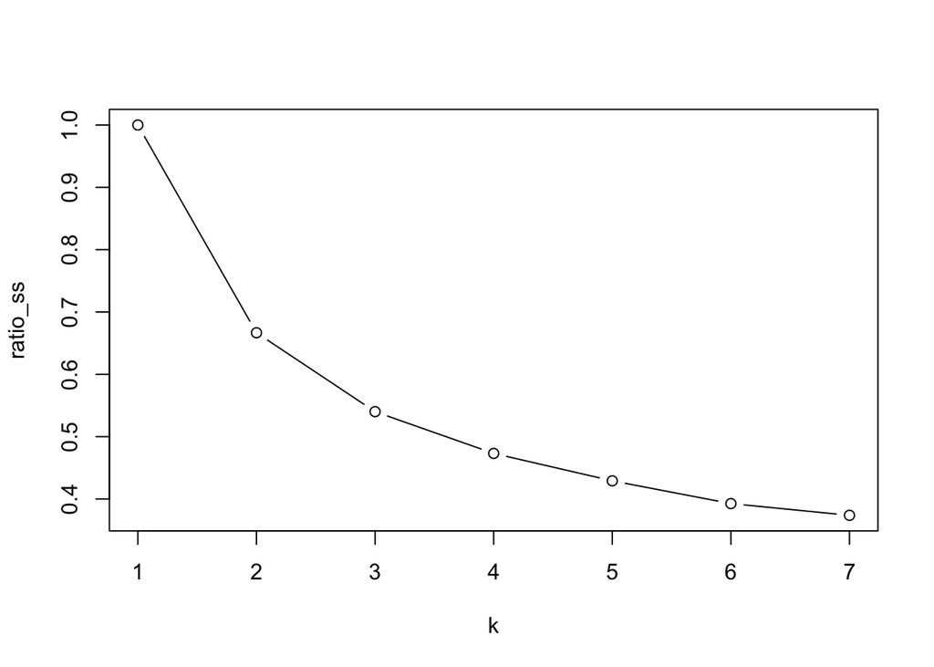

````
From the scree plot, we can tell that the 2-cluster or 3-cluster solution is worth trying. We chose k=3 for the  detailed analysis here but we would also consider the 2-cluster solution in the evaluation stage using ```clValid```.
````

```r
  # Initialise ratio_ss
  ratio_ss <- rep(0, 7)

  # Finish the for-loop
  for (k in 1:7) {
    # Apply k-means to data_final: data_km
     data_km <- kmeans(data_final, k, nstart = 20)
    # Save the ratio between of WSS to TSS in kth element of ratio_ss
    ratio_ss[k] <- data_km$tot.withinss / data_km$totss
  }
  # Make a scree plot with type "b" and xlab "k"
  plot(ratio_ss, type = "b", xlab = "k")
```

Then we used k means function with the cluster number of 3, `nstart =20` means that the algorithm attempts 20 initial trials and returns the best clustering result.

```r
  km_result <- kmeans(data_final, 3, nstart = 20)

  data_final%>%
    mutate(cluster = factor(km_result$cluster)) %>%
     {.} -> data_km
```

The corresponding cluster solution was saved in a new column named `cluster`. The new data set was named as `data_km`.

We also used the `dplyr` function to examine the size of each cluster.

```r
    data_km %>%
    group_by(cluster) %>%
       dplyr::summarise(COUNT = n())
```

```
## # A tibble: 3 × 2
##   cluster COUNT
##    <fctr> <int>
## 1       1   946
## 2       2  2142
## 3       3  1440
```

## 3.5 Cluster Analysis process - Partitioning Around Mediods (PAM)

Then we used the PAM method.

To determine the optimal number of clusters for Partitioning Around Mediods, we calculated the *silhouette* width for cluster numbers from 2 to 10 and plotted a scree plot.

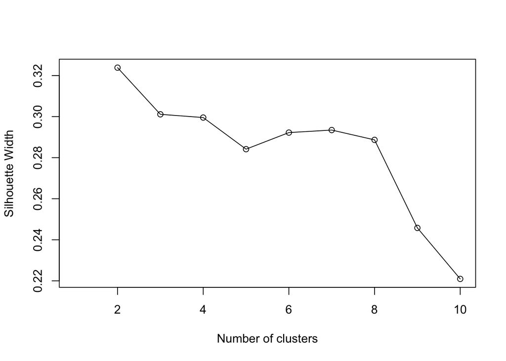

```r
  # Calculate silhouette width for many k using PAM
  sil_width <- c(NA)

  for(i in 2:10){
    pam_fit <- pam(data_final,diss=FALSE,
                   k = i)
    sil_width[i] <- pam_fit$silinfo$avg.width
  }

  plot(1:10, sil_width,
       xlab = "Number of clusters",
       ylab = "Silhouette Width")
  lines(1:10, sil_width)
```

From the scree plot, we can see the 2-cluster solution has the greatest Silhouette Width values 0.32. Still, the Silhouette Width is very low, which suggests the observations were not effectively clustered into different groups.

## 3.6 Cluster Analysis process - Hierarchical

The last method we used was Hierarchical Clustering Analysis.

We used the `dist` function to calculate the Euclidean distance for our observations and then used `hclust` function to cluster the observations.

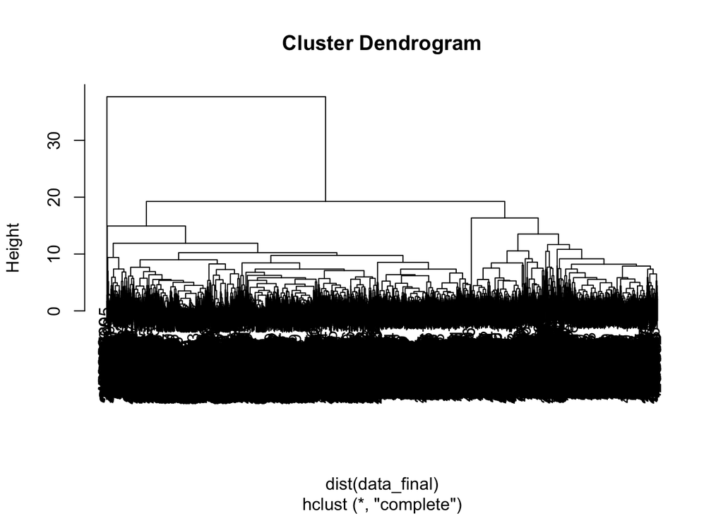

```r
  hclust_result = hclust(dist(data_final))
  plot(hclust_result, label=data_final$NPT4_Pulic)
```

A dengogram was also generated to help select the number of clusters. Due to the large size of our data set, there was not much useful information we could extract from the bottom part of the dengogram. However, there are clearly two very distinct groups at the top of the dengogram. It looks like either two or three groups might be a good place to start investigating.

We tried both 2-cluster and 3-cluster solutions as follows:

```r
  data_final %>%
    mutate(hc_cluster2 = factor(cutree(hclust_result,k=2)),hc_cluster3 =factor(cutree(hclust_result,k=3)) ) %>%
     {.} -> data_hc
```

The clustering result for each observation was stored in two new columns named `hc_cluster2` and `hc_cluster3`, the updated data set was named with `data_hc`. Before we interpreted the cluster solutions, we used `clValid` function in the following section to validate and finalize the optimum cluster solution.

## 3.7 Cluster Validations and Comparisons

To compare the different clustering methods and choose the optimum number of clusters, we ran a cluster validation using `clValid` function. This function allows us to compare the multiple clustering evaluation metrics under different clustering methods as well as different cluster numbers.

```r
  #rownames(data_final) = 1:4528
  methods.vec = c("hierarchical","kmeans","pam")
  clValid.result = clValid(data_final,
                           2:5,
                           clMethods=methods.vec,
                           validation="internal",
                           maxitems = 2000000)
  summary(clValid.result)
```

```
##
## Clustering Methods:
##  hierarchical kmeans pam
##
## Cluster sizes:
##  2 3 4 5
##
## Validation Measures:
##                                   2        3        4        5
##
## hierarchical Connectivity    4.3825  52.1210  52.1210  64.6948
##              Dunn            1.7514   0.1004   0.1004   0.1011
##              Silhouette      0.8290   0.3457   0.3107   0.2541
## kmeans       Connectivity    4.3825 221.0500 541.0579 576.7075
##              Dunn            1.7514   0.0279   0.0240   0.0098
##              Silhouette      0.8290   0.3350   0.2271   0.2627
## pam          Connectivity  230.6532 407.1829 433.3655 337.9710
##              Dunn            0.0166   0.0058   0.0130   0.0083
##              Silhouette      0.3239   0.3011   0.2996   0.2842
##
## Optimal Scores:
##
##              Score  Method       Clusters
## Connectivity 4.3825 hierarchical 2
## Dunn         1.7514 hierarchical 2
## Silhouette   0.8290 hierarchical 2
```

The result shows that the optimum number of cluster is 2, and the best method is hierarchical.

In the following session, we first analyzed the 2-cluster solution in details.

```r
  #two cluster solutions
  data_hc %>%
    group_by(hc_cluster2) %>%
       dplyr::summarise(COUNT = n())
```

```
## # A tibble: 2 × 2
##   hc_cluster2 COUNT
##        <fctr> <int>
## 1           1  4524
## 2           2     4
```

From the output for the two cluster solutions, the first cluster has 4,524 observations while the second cluster has only 4 observations. The unbalanced distribution makes the clustering result less meaningful because the profile of second cluster is not general enough. Therefore, after examining the table produced by `clValid` above, we decided to select the hierarchical method with 3-cluster solution as our final cluster solution.

## 3.8 The Interpretation of 3 cluster hierachical solutions

We used the following code to generate the histogram for hierarchical 3-Cluster Solution.

```r
#three cluster solutions
data_hc %>%
    group_by(hc_cluster3) %>%
       dplyr::summarise(COUNT = n())
```

```
## # A tibble: 3 × 2
##   hc_cluster3 COUNT
##        <fctr> <int>
## 1           1  2992
## 2           2  1532
## 3           3     4
```

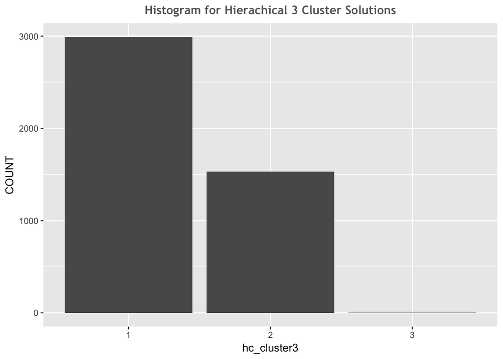

```r
data_hc %>%
  group_by(hc_cluster3) %>%
     dplyr::summarise(COUNT = n()) %>%
       ggplot(aes(x = hc_cluster3, y = COUNT)) + geom_bar(stat = "identity") + ggtitle('Histogram for Hierachical 3 Cluster Solutions') + theme(plot.title = element_text(family = "Trebuchet MS", color="#666666", face="bold", size=12, hjust=0.5))
```

Based on the output, the first cluster has 2,992 observations, the second cluster has 1,532 observations while the third cluster has 4 observations.

We first looked at the third cluster to see what makes these observations different from others.

```r
#select the cluster 3 membership from the original dataset
cluster3 = subset(data_c, UNITID %in% rownames(subset(data_hc,hc_cluster3==3)))[,-1]
cluster3[,1:5]
```

```
##      UNITID                            INSTNM_factor STABBR_factor
## 7264 475750              Carrington College-Mesquite            TX
## 7281 476230 Ross Medical Education Center-Morgantown            WV
## 7400 480356        InterCoast Career Institute-Salem            NH
## 7404 480523     Ross Medical Education Center-Dayton            OH
##      PREDDEG_factor     Control_factor
## 7264  NotClassified Private For-profit
## 7281  NotClassified Private For-profit
## 7400  NotClassified Private For-profit
## 7404  NotClassified Private For-profit
```

Based on the output, we can tell that all of these four universities are all private for-profit with a *Not-Classified* predominant degree. Institutions in this cluster have a higher percent of pell grant, higher loan amount and a higher percent of first-generation students compared to the other two clusters.

Then We calculated the median value of each column grouped by cluster.

```r
#three cluster solution summary statistics
data_hc[,-21]%>%
  group_by(hc_cluster3) %>%
     dplyr::summarise_each(funs(median))
```

```
## # A tibble: 3 × 21
##   hc_cluster3 NPT4_COMBINE DEP_STAT_PCT_IND PAR_ED_PCT_1STGEN  MD_FAMINC
##        <fctr>        <dbl>            <dbl>             <dbl>      <dbl>
## 1           1  -0.06819473        0.5952122         0.5009495 -0.6030092
## 2           2   0.19847768       -1.1131175        -0.9513028  0.9382899
## 3           3  -0.01766219        0.9190994         0.8610346 -0.7091410
## # ... with 16 more variables: PCTPELL <dbl>, PCTFLOAN <dbl>,
## #   GRAD_DEBT_MDN <dbl>, WDRAW_DEBT_MDN <dbl>, APPL_SCH_PCT_GE2 <dbl>,
## #   MD_EARN_WNE_P6 <dbl>, MD_EARN_WNE_P10 <dbl>, RPY_3YR_RT_SUPP <dbl>,
## #   CDR3 <dbl>, Associate.s.degree <dbl>, Bachelor.s.degree <dbl>,
## #   Certificate.degree <dbl>, NotClassified <dbl>,
## #   Private.For.profit <dbl>, Private.Nonprofit <dbl>, Public <dbl>
```

We can tell that the schools in cluster 1 are the TITLE IV institutions with low average net price, high percentage of first-generation students, low median family income, high percentage of Pell Grant receiving students, high federal loan, low median debt, low median income six years after entry, low median income ten years after entry and low repayment rate 3 years after entering repayment. **To summarize, students in these institution tend to from a less wealthy background, who need more financial aid and make less money after graduation**

Institutions in cluster 2 are opposite to those in cluster 1. **The students from these institutions are from a more well-educated and wealthy family and are more willing to invest money in education through student loan or family support. These students also make more money after graduation.**

Then we created some visualizations to help us explore the relationships between variables in each cluster. First we plotted `earnings` against `percentage of Pell Grant`.

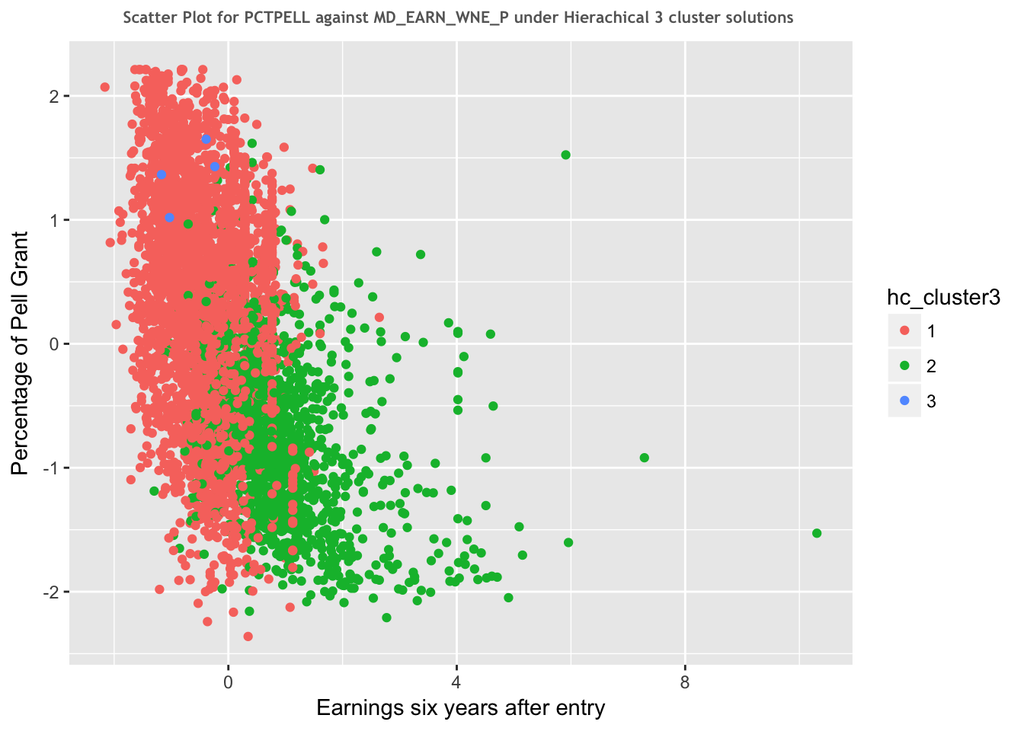

```r
#ggplot
data_hc %>%
  ggplot(aes(x=MD_EARN_WNE_P6, y=PCTPELL)) +
  geom_point(aes(color=hc_cluster3)) +
  guides(size=FALSE) + ggtitle('Scatter Plot for PCTPELL against MD_EARN_WNE_P under Hierachical 3 cluster solutions ') + theme(plot.title = element_text(family = "Trebuchet MS", color="#666666", face="bold", size=8, hjust=0.5)) +
    xlab("Earnings six years after entry")+
    ylab("Percentage of Pell Grant")
```

From the scatter plot, it is easy to tell that the institutions in the cluster 1 have more students who received the Pell Grant meanwhile the students’ median earnings 6 years after the enrollment are relative low compared to the institutions from the cluster 2.

Likewise, we explored the distributions about earnings for each cluster as below:

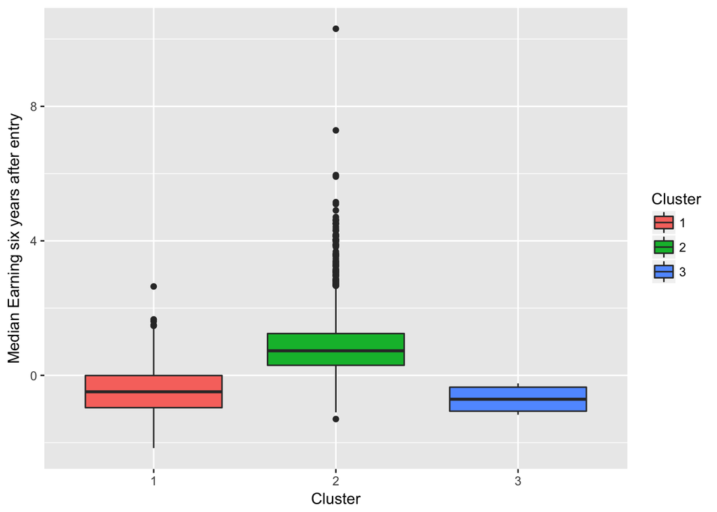

```r
data_hc %>%
  ggplot(aes(x = hc_cluster3,
             y = MD_EARN_WNE_P6)) +
  geom_boxplot(aes(fill = hc_cluster3)) +
  xlab("Cluster") +
  ylab("Median Earning six years after entry") +
  scale_fill_discrete(name = 'Cluster')
```

We also plotted median family income against earnings after six years of entry for each cluster.

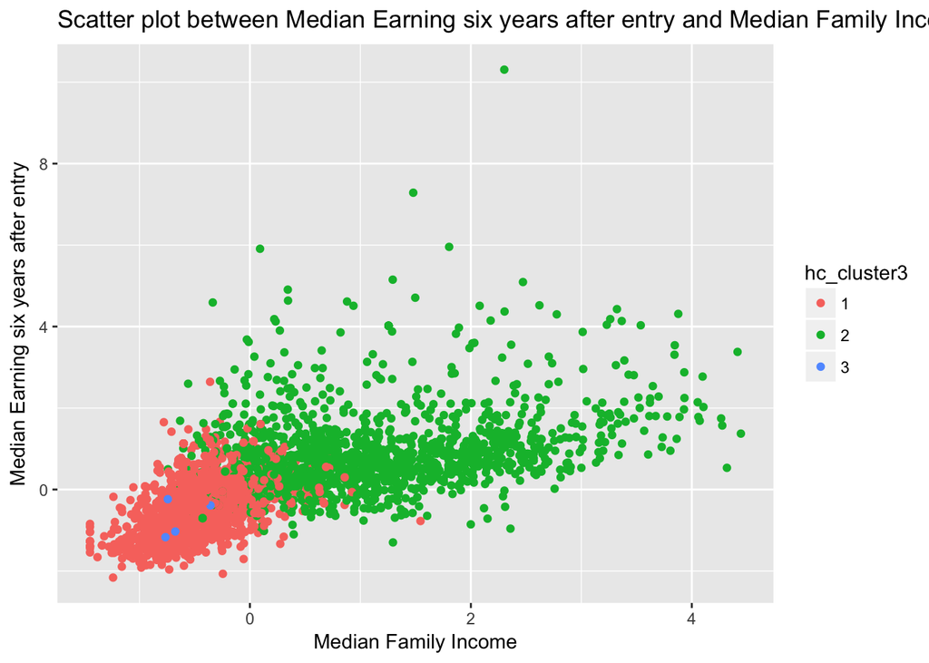

```r
qplot(data = data_hc,
      x = MD_FAMINC,
      y = MD_EARN_WNE_P6,
      color = hc_cluster3,
      xlab = 'Median Family Income',
      ylab = "Median Earning six years after entry",
      main = "Scatter plot between Median Earning six years after entry and Median Family Income and")
```

We see that the most observations in cluster 2 have a higher value for both `Median Family Income` and `Median Earning six years after entry`.

## 3.9 Findings and Conclusion

To find the intrinsic groups in the College Scorecard data set, we have used K-means, PAM and Hierarchical methods to perform clustering analysis. The cluster solutions for each method were different so we used metrics such as *Connectivity*, *Dunn Index* and *Silhouette width* to evaluate the clustering performance.

The optimal clustering solution we found was Hierarchical method with 3 clusters. When selecting the optimal clustering solution, not only did we take into account the clusters performance indicated by evaluation metrics but also we used human judgement on the meaningfulness of the clustering result. **As a result, we dropped the best result generated by computer - Hierarchical with 2 clusters, and go with the Hierarchical with 3 clusters**.

The final three clusters contain 2,992 observations, 1,532 observations and 4 observations respectively. It’s unusual that one cluster only contains 4 observation, which may not be able to provide us with meaningful insights. In the future, an alternative study we would consider is to treat these 4 observations as outliers and do another cluster analysis without these 4 observations, and then compare if the two results are different.

The result shows that the students from cluster 1 institutions are more likely to from less wealthier family and more likely to apply for pell grant. These students also tend to make less money after graduation. In contrast, the students from cluster 2 institutions are more likely to from a well-educated and wealthy family, and make more money after graduation.

# 4.Future Study

The association rules we have generated from this study can be used to determine the candidate predictors for predicting colleges’ post-graduation earnings in the future stages. Likewise, clustering result also can be used as a new input in the predictive model.

In terms of the solution we have selected for the cluster analysis, the results could be improved by investigating on the 4 observations (the observations in the cluster 3 generated by the computer). The analysis process covered in this paper could be revised if the 4 observations in the cluster 3 are outliers. Moreover, a density-based cluster method like DBSCAN can be included in the analysis process as well.